# RMarkdown - January 2019 Data Carpentry Lesson

Maria Kamenetsky

January 17, 2019

# Outline

- 0. Why RMarkdown
- 1. Basics of RMarkdown
- 2. Rcode chunks
- 3. Code chunk options
- 4. Inline R code
- 5. Other Output formats

# Why `RMarkdown`?

- combines text, code, figures, tables
- write papers without having to remember to swap figures, change cell values in table.
- automatically generate reports
- *reproducible* documents

# 1) RMarkdown Basics

**RStudio -> File -> New File ->R Markdown** (keep defaults, add title)

[figure not shown]

Prompt to start new RMarkdown document.

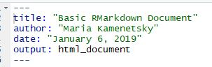

Header for RMarkdown document.

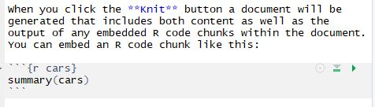

Text and code chunk.

## Markdown:

1. system for writing web pages, marking up text (like in an email).
2. Marked up text gets converted to html, with *marks* replaced by proper html code.
- Markdown Basics:
  - **a bolded statement**
  - *an italicized statement*
  - code-type font: `code-type font`
  - this is a bulleted list
1. A numbered
2. List
3. Can be made
4. Like this

```r
1. A numbered
1. List
1. Can be made
1. Like this
```

**HTML** Headers:

```r
#Header 1
##Header 2
###Header 3
```

# Header 1

## Header 2

### Header 3

*Delete default RMarkdown text (except global options)*

```r
# Add Some Notes
## Reflections on Markdown So Far

Markdown is **super** awesome, I'm *not* even joking.

Why I love `RMarkdown`:

1. It makes things reproducible
2. Easy to collaborate
3. It's fun!
```

# Add Some Notes

## Reflections on Markdown So Far

Markdown is **super** awesome, I’m *not* even joking.

Why I love `RMarkdown`:

1. It makes things reproducible
2. Easy to collaborate
3. It’s fun!

*Generate basic RMarkdown document.*

#### **CHALLENGE 1**: Make a new RMarkdown document. Delete all of the R code chunks and write a bit of Markdown (some sections, italicized/bold text, itemized list). Knit to HTML

## More Markdown (if time allows)

- add a hyperlink: `[text to show](http://the-web-page.com)`
- include an image: `![image caption](http://url/for/file)`
- Sub-script (F<sub>2</sub>): `F~2~` and super-script ( F<sup>2</sup>): `F^2^`.
- LaTeX code: ($E=mc^2$) `$E=mc^2$` or formulas:
  $$y = \mu + \sum_{i=1}^p \beta_i x_i + \epsilon$$
  (`$$y = \mu + \sum_{i=1}^p \beta_i x_i + \epsilon$$`).

# 2)R code chunks

A main code chunk:

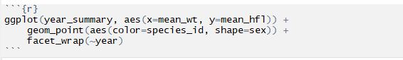

Code chunk example

Place R code between the sets of ticks. You may also give each code chunk a name, which can help you find errors:

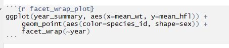

Named code chunk example

Can create a new code chunk manually (with backticks) or short-cut: **CTRL+ALT+i**.

[Importing surveys dataset into RMarkdown and creating a visualization with R code chunk options.]

```r
library(ggplot2)
library(dplyr)
```

```r
download.file("http://kbroman.org/datacarp/portal_clean.csv", "portal_clean.csv")
surveys <- read.csv("portal_clean.csv")
```

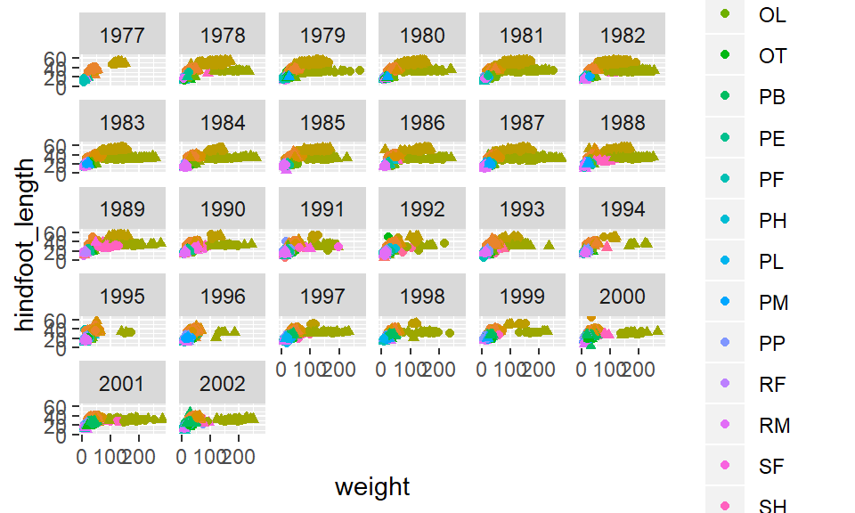

```r
ggplot(surveys, aes(x=weight, y=hindfoot_length)) +
   geom_point(aes(color=species_id, shape=sex)) +
  facet_wrap(~year)
```

#### **CHALLENGE 2**: Add code chunks to load ggplot2 package, read in portal data, create a plot.

# 3) Code chunk options

- customize R chunk output

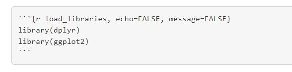

Example of R code chunk options specifyin that the code should not be output in the final report (echo=FALSE) and any messaged should also be suppressed (message=FALSE)

- Useful code chunk options:
  - `echo=FALSE`: supress code from being printed in final report
  - `results="hide"`: avoid having any results printed.
  - `eval=FALSE`: do not evaulate the code in the chunk.
  - `warning=FALSE` and `message=FALSE` hides any warnings or messages produced.
  - `fig.height`, `fig.width` controls size of figures (in inches).
  - `fig.cap`: adds a caption to the figures.
  - `fig.path`: defines path where figures will be saved. Example: `..., fig.path="Figs/",...`
- code chunk options can be set locally (for each code chunk) or globally (for the entire RMarkdown document)

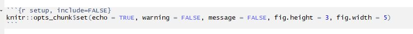

Global code chunk example

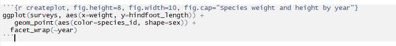

Plot with chunk options example

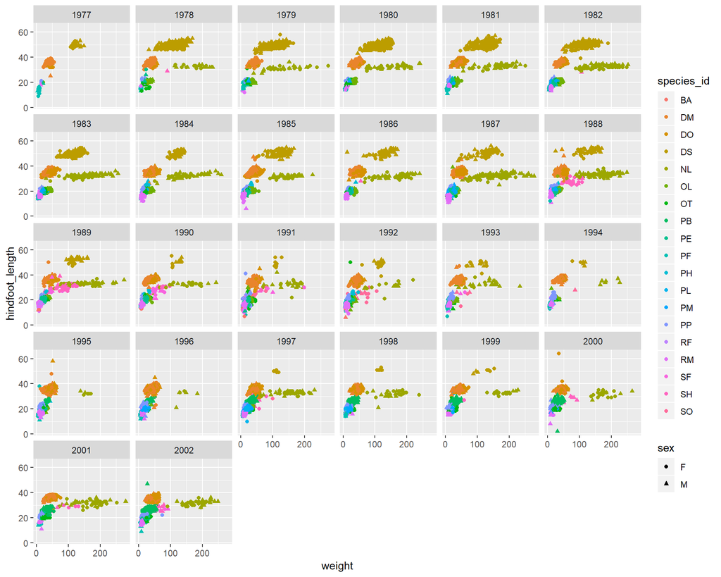

Species weight and height by year

#### **CHALLENGE 3**: Use chunk options to control the size of a figure and hide the code.

# 4) Inline R Code

- You can make every number in your report reproducible in the text. Use `` `r `` and `` ` `` for an in-line code chunk.
  - For example: `` `r round(some_value, 2)` ``. The code will be executed and replaced with the value of the result.
- Don’t let these R chunks split across lines - they will not work.
- If you have some calculations to do, you can have a preceeding R chunk to calculate the results, hide the code and results using `echo=FALSE` and `results="hide"` (which is equivalent to `include=FALSE`).

##### **CHALLENGE 4**: Try out in-line code in R

```r
surveys <- read.csv("portal_clean.csv")
```

```r
There are `r nrow(surveys)` observations in the *surveys* dataset.
```

There are 30652 observations in the *surveys* dataset.

# 5) Other Output formats

(May take some additional installation on your computer)

In addition to HTML documents, RMarkdown can also *knit* to PDF or Word documents.

[figure not shown]

Other output format options

# Resources

- [Knitr in a knutshell tutorial](http://kbroman.org/knitr_knutshell)
- [Dynamic Documents with R and knitr](http://www.amazon.com/exec/obidos/ASIN/1482203537/7210-20) (book)
- [R Markdown documentation](http://rmarkdown.rstudio.com)
- [R Markdown cheat sheet](http://www.rstudio.com/wp-content/uploads/2015/02/rmarkdown-cheatsheet.pdf)